# ADOLECENT REPRODUCTIVE HEALTH BEHAVIOR AMONG GIRLS AGED 15-19

OKELLO DANIEL

2025-06-29

# Introduction

This monograph presents an AI-assisted analysis of adolescent reproductive health indicators among girls aged 15-19 in Uganda, leveraging advanced automated data analysis capabilities using Cursor, a modern AI-powered development environment. The analysis utilizes data from the 2016 Uganda Demographic and Health Survey (UDHS), a nationally representative dataset that provides comprehensive insights into the reproductive health and demographic characteristics of the population. Specifically, it examines marital status among adolescent girls aged 15–19, disaggregated by residence, education level, and household wealth status. In addition, the analysis investigates the age at first sexual intercourse by place of residence, as well as the current pregnancy status of adolescents.

# Marital Status

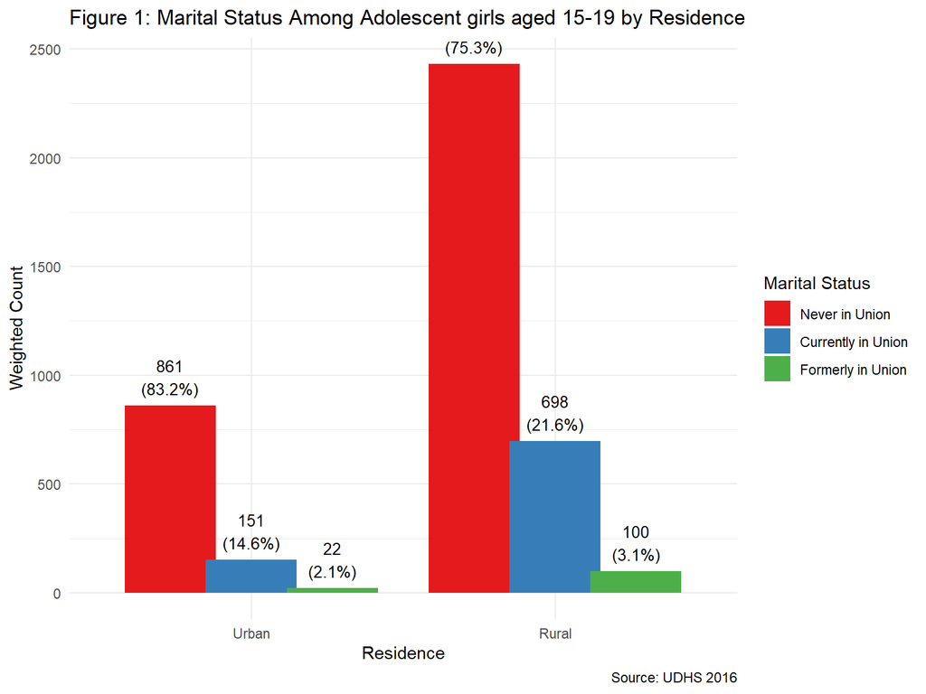

Figure 1 shows marital status of adolescent girls aged 15–19 years, disaggregated by urban and rural residence. In urban areas, the majority of adolescent girls (83.2%) have never been in a union, while 14.6% are currently in a union, and only 2.1% were formerly in a union. In contrast, in rural areas, a smaller proportion (75.3%) have never been in a union, while a notably higher 21.6% are currently in a union, and 3.1% were formerly in a union.

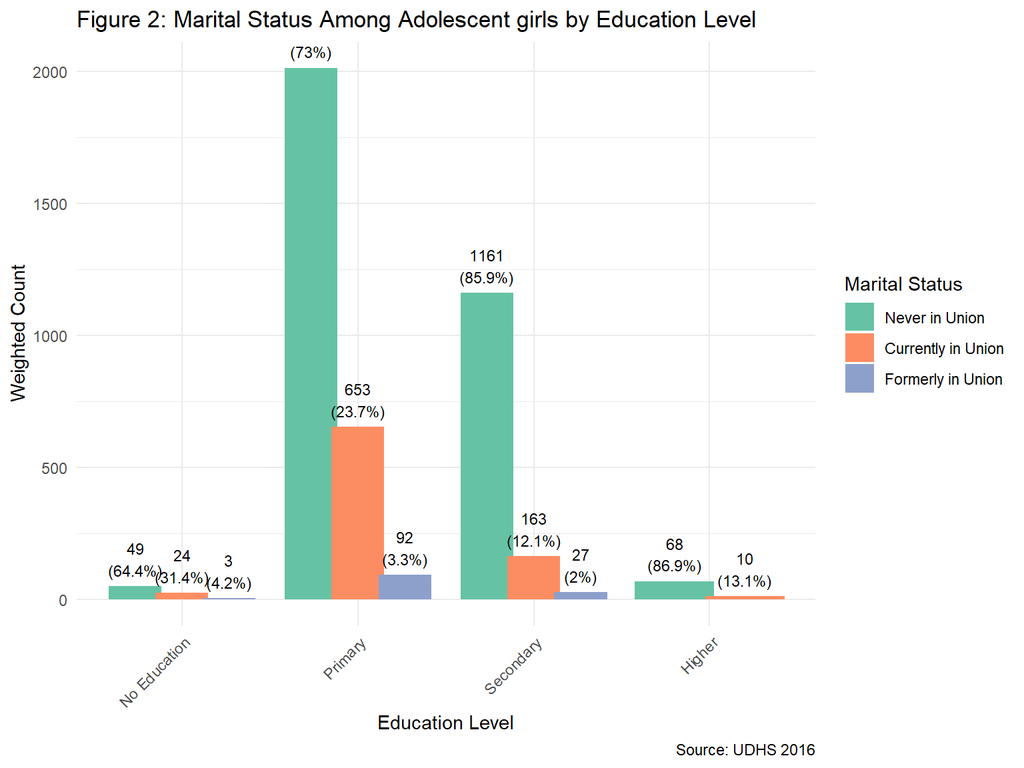

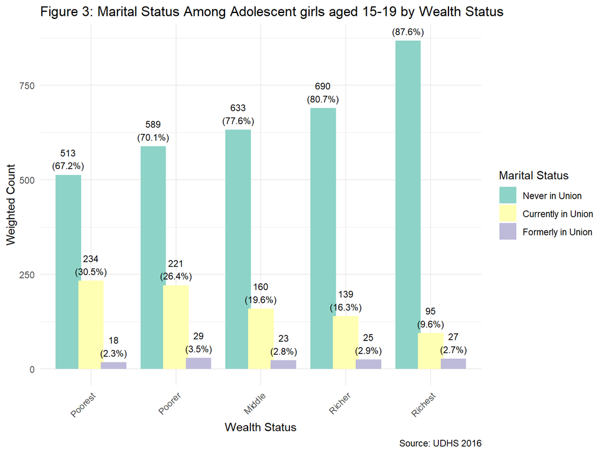

Figure 3 presents the marital status of adolescent girls across different wealth quintiles. In the poorest quintile, 30.5% are currently in a union, compared to just 9.6% in the richest quintile. The proportion of adolescent girls who have never been in a union increases steadily with wealth, from 67.2% (poorest) to 87.6% (richest). Former unions remain relatively low and fairly constant across all wealth groups. This shows that adolescent girls from wealthier households are less likely to be married compared to those from poorer backgrounds, indicating that poverty may be a contributing factor to early marriage.

# Age at First Sex

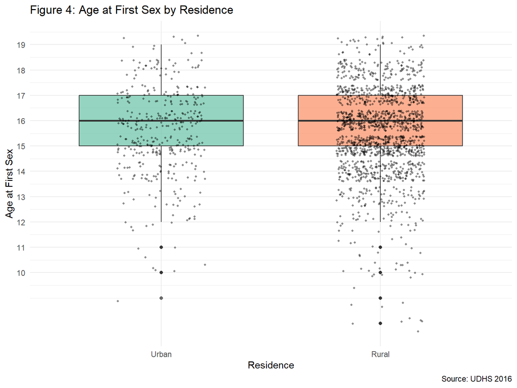

# Pregnancy Status

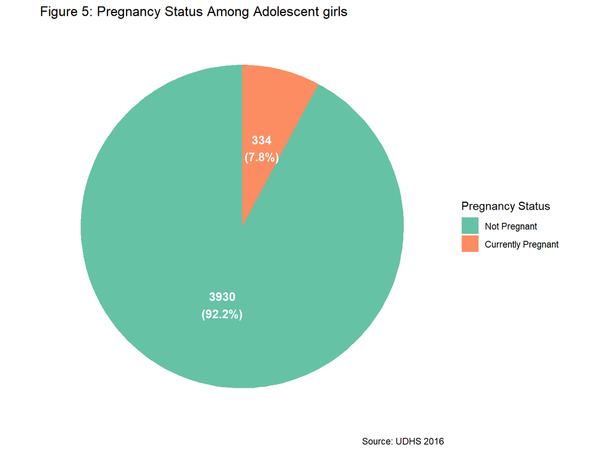

Figure 5 displays the distribution of current pregnancy status among adolescent girls aged 15–19. Ninety two percent of adolescent girls are not pregnant, while 7.8% are currently pregnant. Although the majority of adolescent girls are not pregnant at the time of the survey, a notable 7.8% pregnancy rate among 15–19-year-olds highlights a significant concern for adolescent girls reproductive health in Uganda.